# Fetal Electrocardiogram Extraction by Source Subspace Separation

#### By Kevin Hughes and Andreas Ziehe

This notebook illustrates [Blind Source Seperation](http://en.wikipedia.org/wiki/Blind_signal_separation)(BSS) on several time synchronised Electrocardiogram's (ECG's) of the baby's mother using [Independent Component Analysis](http://en.wikipedia.org/wiki/Independent_component_analysis) (ICA) in Shogun. This is used to extract the baby's ECG from it.

This task has been studied before and has been published in these papers:

Cardoso, J. F. (1998, May). Multidimensional independent component analysis. In Acoustics, Speech and Signal Processing, 1998. Proceedings of the 1998 IEEE International Conference on (Vol. 4, pp. 1941-1944). IEEE.

Dirk Callaerts, "Signal Separation Methods based on Singular Value Decomposition and their Application to the Real-Time Extraction of the Fetal Electrocardiogram from Cutaneous Recordings", Ph.D. Thesis, K.U.Leuven - E.E. Dept., Dec. 1989.

L. De Lathauwer, B. De Moor, J. Vandewalle, "Fetal Electrocardiogram Extraction by Source Subspace Separation", Proc. IEEE SP / ATHOS Workshop on HOS, June 12-14, 1995, Girona, Spain, pp. 134-138.

In this workbook I am going to show you how a similar result can be obtained using the ICA algorithms available in the Shogun Machine Learning Toolbox.

First we need some data, luckily an ECG dataset is distributed in the Shogun data repository. So the first step is to change the directory then we'll load the data.

```python
# change to the shogun-data directory
import os
SHOGUN_DATA_DIR=os.getenv('SHOGUN_DATA_DIR', '../../../data')
os.chdir(os.path.join(SHOGUN_DATA_DIR, 'ica'))
```

```python
import numpy as np

# load data
# Data originally from:
# http://perso.telecom-paristech.fr/~cardoso/icacentral/base_single.html
data = np.loadtxt('foetal_ecg.dat')

# time steps
time_steps = data[:,0]

# abdominal signals
abdominal2 = data[:,1]
abdominal3 = data[:,2]
abdominal4 = data[:,3]
abdominal5 = data[:,4]
abdominal6 = data[:,5]

# thoracic signals
thoracic7 = data[:,6]
thoracic8 = data[:,7]
thoracic9 = data[:,8]
```

Before we go any further let's take a look at this data by plotting it:

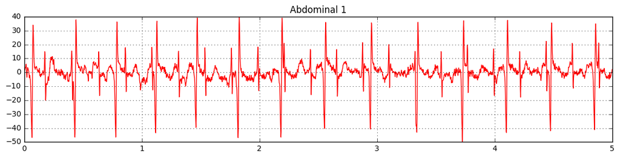

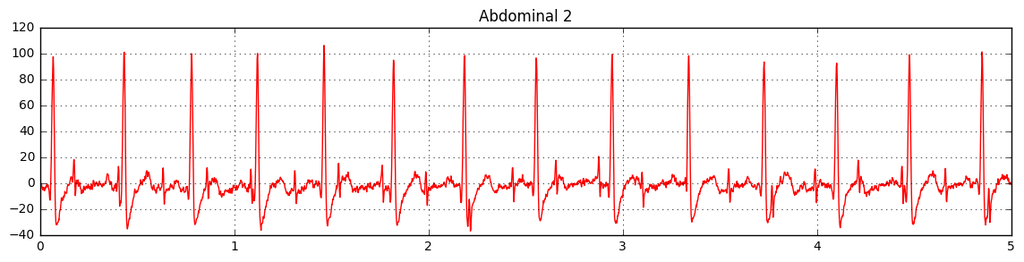

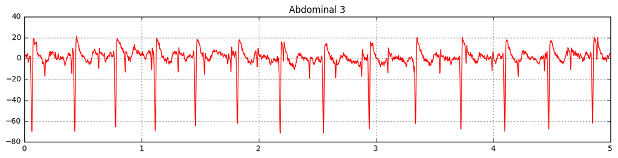

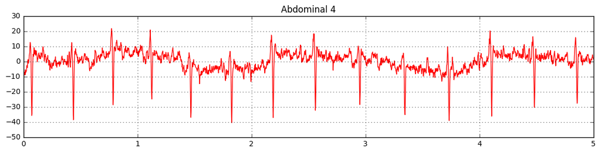

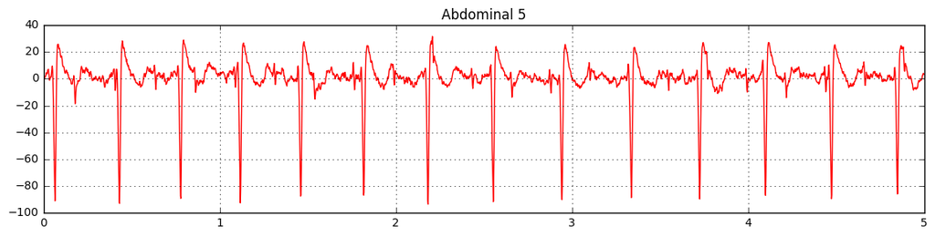

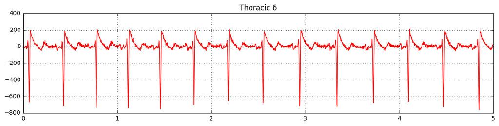

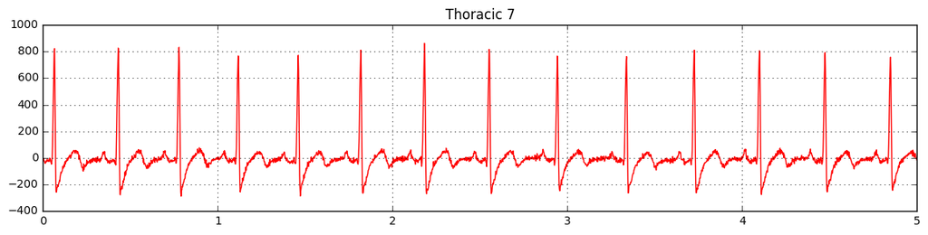

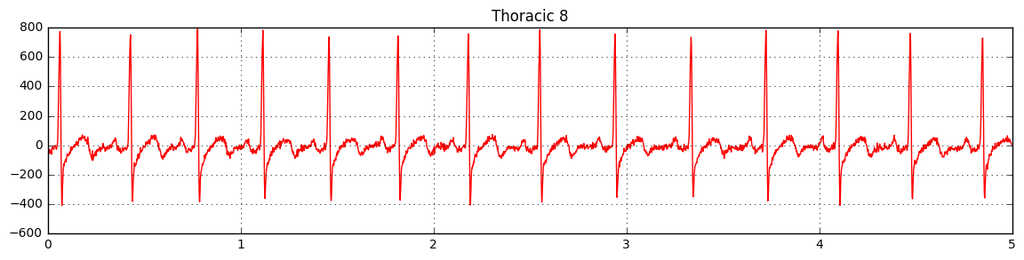

```python
%matplotlib inline
# plot signals
import pylab as pl

# abdominal signals
for i in range(1,6):
    pl.figure(figsize=(14,3))
    pl.plot(time_steps, data[:,i], 'r')
    pl.title('Abdominal %d' % (i))
    pl.grid()
    pl.show()

# thoracic signals
for i in range(6,9):
    pl.figure(figsize=(14,3))
    pl.plot(time_steps, data[:,i], 'r')
    pl.title('Thoracic %d' % (i))
    pl.grid()
    pl.show()
```

The peaks in the plot represent a heart beat but its pretty hard to interpret and I know I definitely can't see two distinc signals, lets see what we can do with ICA!

Now we create our ICA data set and convert to a Shogun features type:

```python
from shogun import RealFeatures

# Signal Matrix X
X = (np.c_[abdominal2, abdominal3, abdominal4, abdominal5, abdominal6, thoracic7,thoracic8,thoracic9]).T

# Convert to features for shogun
mixed_signals = RealFeatures((X).astype(np.float64))
```

Next we apply the ICA algorithm to separate the sources:

```python
from shogun import SOBI

# Separating with SOBI
sep = SOBI()
sep.set_tau(1.0*np.arange(0,120))

signals = sep.apply(mixed_signals)

S_ = signals.get_feature_matrix()
```

And we plot the separated signals:

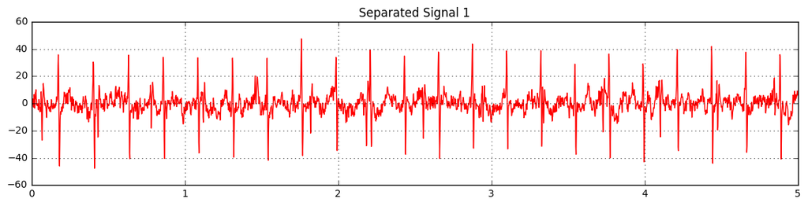

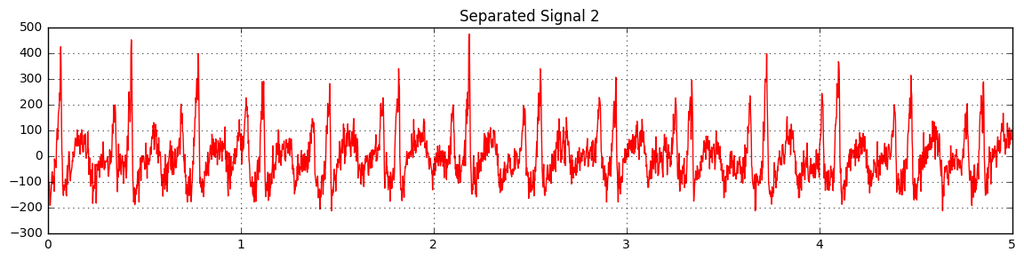

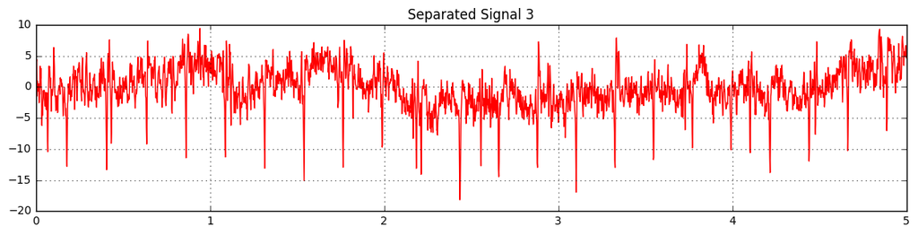

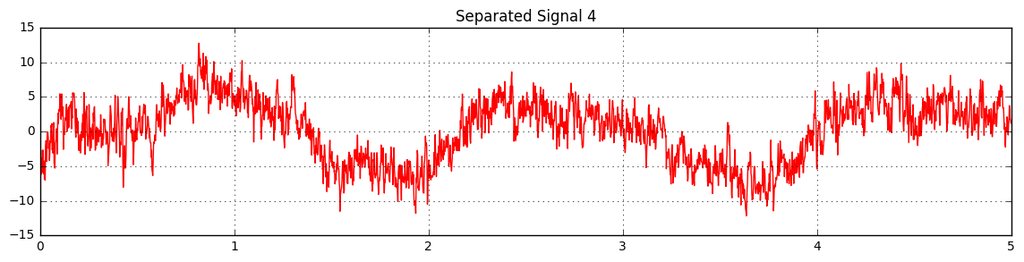

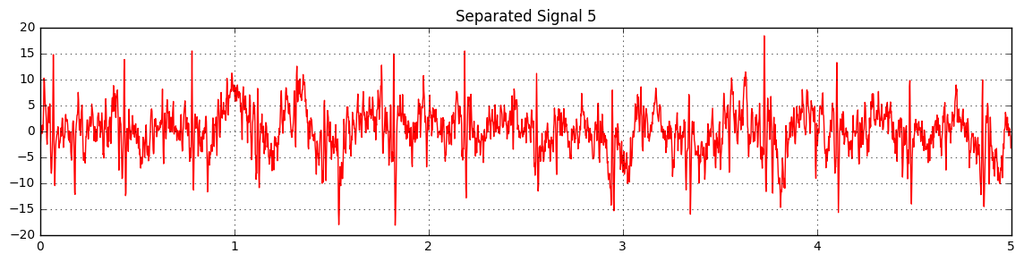

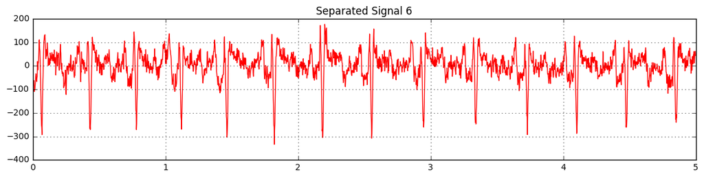

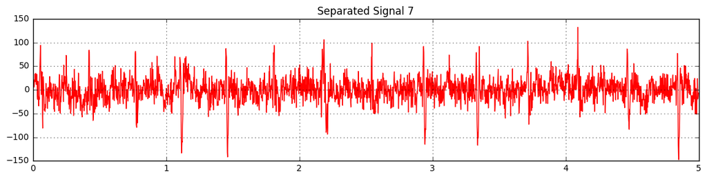

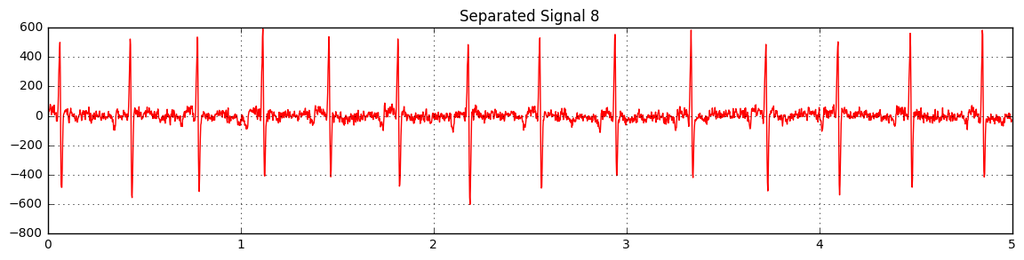

```python
# Show separation results

# Separated Signal i
for i in range(S_.shape[0]):
    pl.figure(figsize=(14,3))
    pl.plot(time_steps, S_[i], 'r')
    pl.title('Separated Signal %d' % (i+1))
    pl.grid()
    pl.show()
```

Now we can interpret the results! First we are going to exploit the known fact that the baby's heart rate is about twice that of the mothers.

Our interpretation of the results is as follows:

- separated signal 1 -> baby ECG
- separated signal 2 -> still a bit mixed baby +mother
- separated signal 3 -> baby ECG
- separated signal 4 -> slow drift due to breathing of the mother
- separated signal 5 -> mainly mother ECG but still a bit mixed and noisy
- separated signal 6-8 -> mothers ECG, with 8 being the best

And thats the proof of concept Fetal Electrocardiogram Extraction by Source Subspace Separation using the Shogun Machine Learning Toolkit!